# Solutions

# Section 1

##### Exercise 1

(well-known) You play poker with the Archbishop of Canterbury. It turns out that he has a royal flush, which has a probability of only $1.54 \times 10^{-6}$. However, being a reputable man, you believe it is very unlikely that the Archbishop would cheat – say 1 in a million, $1 \times 10^{-6}$. Use Bayes’ rule to work out the probability that the Archbishop cheated.

```r
numerator <- 10^(-6)
denominator <- 1.54 * 10^(-6) * (1 - 10^(-6)) + 10^(-6)
numerator / denominator
```

```
## [1] 0.393701
```

##### Exercise 2

You play tennis against your friend 5 times. You win 4 times and lose once. Assuming you had no idea how likely you were to win initially, what is the posterior distribution of your win probability (plot it in R)? Draw 10000 samples from the distribution to estimate how likely it is that your win probability is greater than 70%.

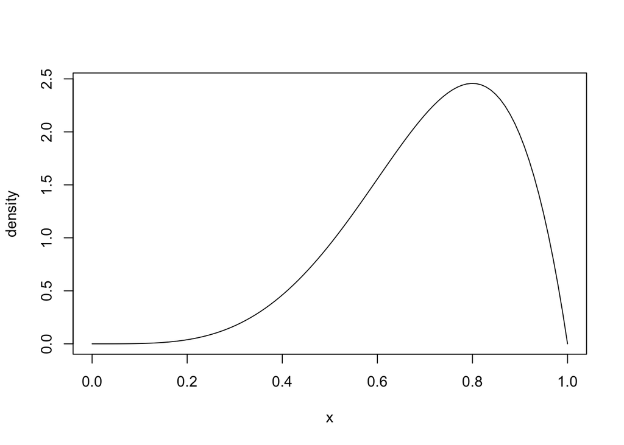

```r
alpha <- 4 + 1
beta <- 1 + 1
x <- seq(0, 1, length.out = 100)

density <- dbeta(x, alpha, beta)

plot(x, density, type='l')
```

```r
mean(rbeta(10000, alpha, beta) > 0.7)
```

```
## [1] 0.5809
```

# Section 2

Exercise 1: What you should see is that there are “divergent transitions” when you remove the <lower=0, upper=1>. And Stan should complain and fail to compile if you get the types wrong. Exercise 2:

```r
library(rstan)
stan_data <- list(
  y = 5,
  n = 10
)

model <- stan_model('./beta_binomial_normal_prior.stan')
model_fit <- sampling(model, data=stan_data)
model_fit
```

```
## Inference for Stan model: beta_binomial_normal_prior.
## 4 chains, each with iter=2000; warmup=1000; thin=1;
## post-warmup draws per chain=1000, total post-warmup draws=4000.
##
##        mean se_mean   sd   2.5%   25%   50%   75% 97.5% n_eff Rhat
## theta  0.49    0.00 0.13   0.23  0.40  0.49  0.58  0.74  1575    1
## lp__  -8.93    0.02 0.71 -10.90 -9.06 -8.66 -8.49 -8.44  1648    1
##
## Samples were drawn using NUTS(diag_e) at Mon Aug 12 15:54:36 2019.
## For each parameter, n_eff is a crude measure of effective sample size,
## and Rhat is the potential scale reduction factor on split chains (at
## convergence, Rhat=1).
```

```
## ci_level: 0.8 (80% intervals)
```

```
## outer_level: 0.95 (95% intervals)
```

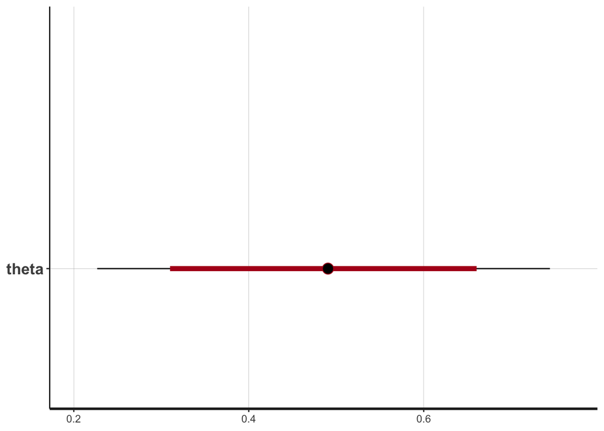

```r
plot(model_fit)
```

So the results look pretty similar. The $\mathcal{N}(0, 1)$ prior is quite vague too. Things might look different if we used a $\mathcal{N}(0, 0.1)$ prior.

## SDM example

Exercise 1: The probability of a positive slope should be 0.739 or thereabouts. Exercise 2:

We need to adapt the stan code:

```
data {
  int n_obs; // Number of observations
  int y[n_obs]; // Presence / absence at each site
  vector[n_obs] x1; // Covariate 1
  vector[n_obs] x2; // Covariate 2
}
parameters {
  real theta_1; // Slope for x1
  real theta_2; // Slope for x2
  real theta_3; // Intercept
}
model {
  // Priors
  theta_1 ~ normal(0, 1);
  theta_2 ~ normal(0, 1);
  theta_3 ~ normal(0, 1);

  y ~ bernoulli_logit(theta_1 * x1 + theta_2 * x2 + theta_3);
}
```

And then we need to add to the data:

```r
x <- read.csv('./x_train.csv', row.names=1)
y <- read.csv('./y_train.csv', row.names=1, check.names=FALSE)

x_scaled <- scale(x)
x1 <- x_scaled[, 1]
x2 <- x_scaled[, 2]

y <- y[, 'Wood Duck']
```

```r
model_data <- list(
  n_obs = length(x1),
  y = y,
  x1 = x1,
  x2 = x2
)
```

```r
model <- stan_model('./log_reg_model_two_covariates.stan')
model_fit <- sampling(model, data=model_data)
model_fit
```

```
## Inference for Stan model: log_reg_model_two_covariates.
## 4 chains, each with iter=2000; warmup=1000; thin=1;
## post-warmup draws per chain=1000, total post-warmup draws=4000.
##
##            mean se_mean   sd    2.5%     25%     50%     75%   97.5% n_eff
## theta_1   -0.23    0.00 0.09   -0.41   -0.29   -0.23   -0.16   -0.04  2757
## theta_2   -0.09    0.00 0.09   -0.28   -0.16   -0.09   -0.03    0.09  2675
## theta_3   -1.99    0.00 0.08   -2.14   -2.04   -1.99   -1.93   -1.84  2783
## lp__    -598.91    0.03 1.22 -602.14 -599.45 -598.60 -598.03 -597.51  1832
##         Rhat
## theta_1    1
## theta_2    1
## theta_3    1
## lp__       1
##
## Samples were drawn using NUTS(diag_e) at Mon Aug 12 15:54:44 2019.
## For each parameter, n_eff is a crude measure of effective sample size,
## and Rhat is the potential scale reduction factor on split chains (at
## convergence, Rhat=1).
```

One remark: if we have many covariates, it can get pretty tedious to write out `theta_1, theta_2...` for each one of them. You can instead define a `vector` of coefficients $\theta$ and a matrix `X` (sometimes called the design matrix), and then compute things using matrices. But I didn’t want to burden you with matrix algebra on top of all the Bayesian stuff. The Stan user guide is a great resource and has one way of doing this:

https://mc-stan.org/docs/2_20/stan-users-guide/hierarchical-logistic-regression.html

## Advanced models

Slope sd:

```
     2.5%       50%     97.5%
0.5639543 0.7193014 0.9559265
```

Slope mean:

```
       2.5%         50%       97.5%
-0.05544002  0.20132234  0.45310641
```

We should get

```
      2.5%        50%      97.5%
-1.2996050  0.2185258  1.7045334
```

For the draws from this learned hierarchical prior. And the fit takes around three times as long for me (~3 minutes).